# Pruebas de Hipótesis con R

## Enunciado

La siguiente base de datos contiene información acerca de incautaciones de bebidas alcohólicas fraudulentas y de contrabando en la ciudad de Medellín en un mes, que afectan los recursos para Salud y Educación en el Departamento de Antioquia y de acuerdo a los resultados se toma decisiones para aumentar o disminuir los controles.

Licores

La base de datos contiene las variables - **TL** (Tipo de Licor) - **PI** (Precio de incautación: se refiere al precio de venta en el establecimiento por unidad) - **GAE** (Grados de Alcohol en etiqueta) - **GAQ** (grados de alcohol en prueba química) - **CE** (Cantidades estandarizadas: número de unidades estandarizadas a 750 ml).

Usando la información de su base de datos responda a las siguientes preguntas.

1. El **precio total** de la incautación se calcula como la cantidad estandarizada por el precio de incautación. ¿Se puede afirmar que el precio total promedio de la incautación es superior a $7’500.000?
2. El **ipoconsumo**, es el impuesto que deja de percibir el Estado para salud y educación, el cual se calcula como: $GAQ \times CE \times 400$ (pesos). ¿Se puede afirmar que el ipoconsumo promedio del ron es inferior al ipoconsumo medio del Whisky? ¿Qué decisión se puede tomar frente al control?
3. El licor incautado se clasifica como “Fraudulento” si los GAE son distintos a los GAQ y como “contrabando” si son iguales. ¿La proporción de licores fraudulentos es superior al 65%? ¿Qué significa éste resultado?
4. Se piensa que los ilegales mezclan el licor con otras sustancias para disminuir los grados de alcohol del licor. ¿Existe evidencia para este planteamiento?
5. De acuerdo con los datos, se sabe que el Aguardiente y el Tequila son los licores con más incautaciones. Desde el equipo de Rentas se sostiene que el Aguardiente es el licor que más se adultera. ¿Es correcta esta afirmación?

## Solución usando R

Lo primero es descargar la base de datos en la carpeta que se considere, luego debemos cargar la base de datos en `RStudio` para realizar los análisis. Antes de comenzar con el análisis necesitamos instalar o cargar las librerías necesarias para el análisis

```r
# Gráficos con estilo
require(ggplot2)
# Pruebas de bondad de ajuste
require(nortest)
# Gráficos QQ-plot con IC
require(qqplotr)
# Importar/Exportar datos de Excel
require(openxlsx)
# Para manipular datos
require(dplyr)
```

El siguiente paso es cargar la base de datos, esto lo podemos realizar directamente de `RStudio` con el siguiente comando:

```r
Licores <- read.xlsx(file.choose(),sheet = 1)
```

Revisemos la estructura de los datos, para verificar si fueron cargados correctamente.

```r
str(Licores)
```

```
## 'data.frame':    300 obs. of  5 variables:
##  $ TL : chr  "Ron" "Aguardiente" "Ron" "Aguardiente" ...
##  $ PI : num  34719 26900 27062 29317 32471 ...
##  $ GAE: num  35 29 35 29 38 29 29 38 35 40 ...
##  $ GAQ: num  30.2 29 32.2 29 32.6 ...
##  $ CE : num  221 253 249 254 267 ...
```

```r
# cambiando caracter por factor
Licores <- Licores %>% mutate_if(is.character,as.factor)
```

### Punto 1

El primer punto nos piden calcular **el precio total** de incautación, y se pregunta si el promedio de esa nueva variable es superior a 7.5 millones. Entonces tenemos las hipótesis:

$$H_o: \mu_{pt} = 7'500.000 \qquad
H_a:\mu_{pt} > 7'500.000$$

Para seleccionar el estadístico de prueba más indicado, debemos probar si la distribución del precio total de incautación es Normal.

$$H_0:PT \sim N(\mu,\sigma^2) \qquad H_a:
PT\not\sim N(\mu,\sigma^2)$$

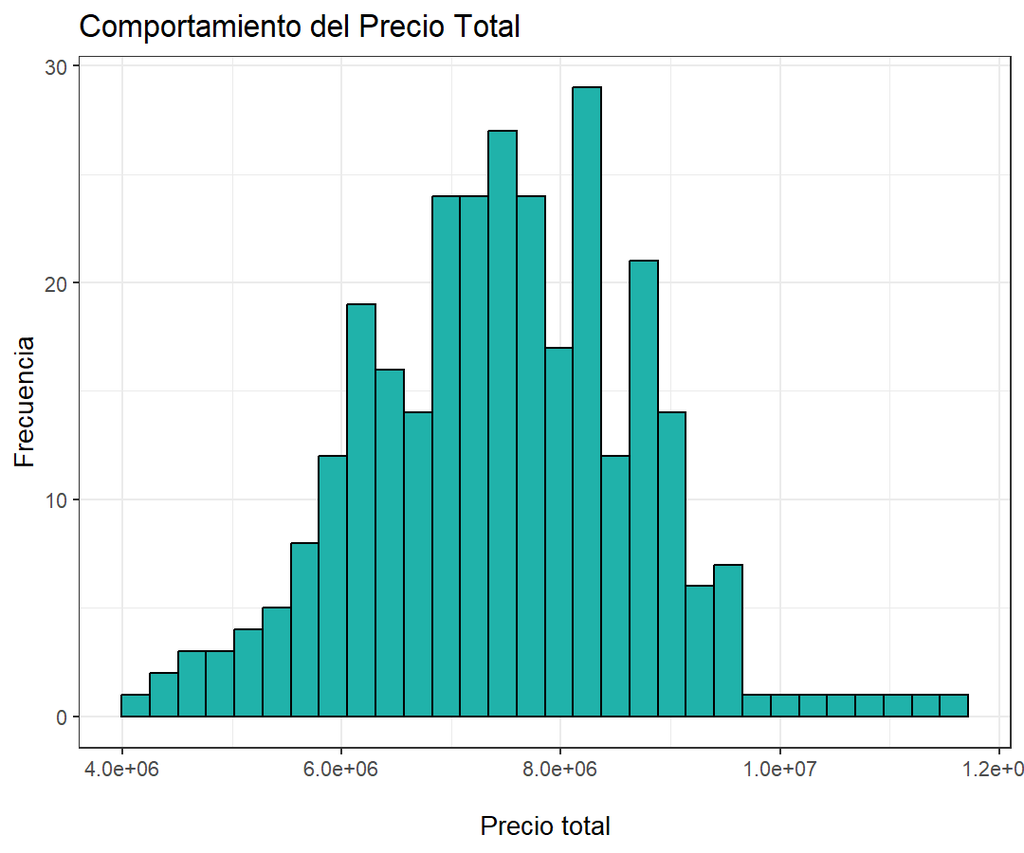

```r
Licores <- Licores %>%
  mutate(PT = CE*PI)

Licores %>%
  ggplot(aes(x=PT))+
  geom_histogram(col=1,bg="lightseagreen")+
  ggtitle("Comportamiento del Precio Total")+
  xlab("\nPrecio total")+ylab("Frecuencia")+
  theme_bw()
```

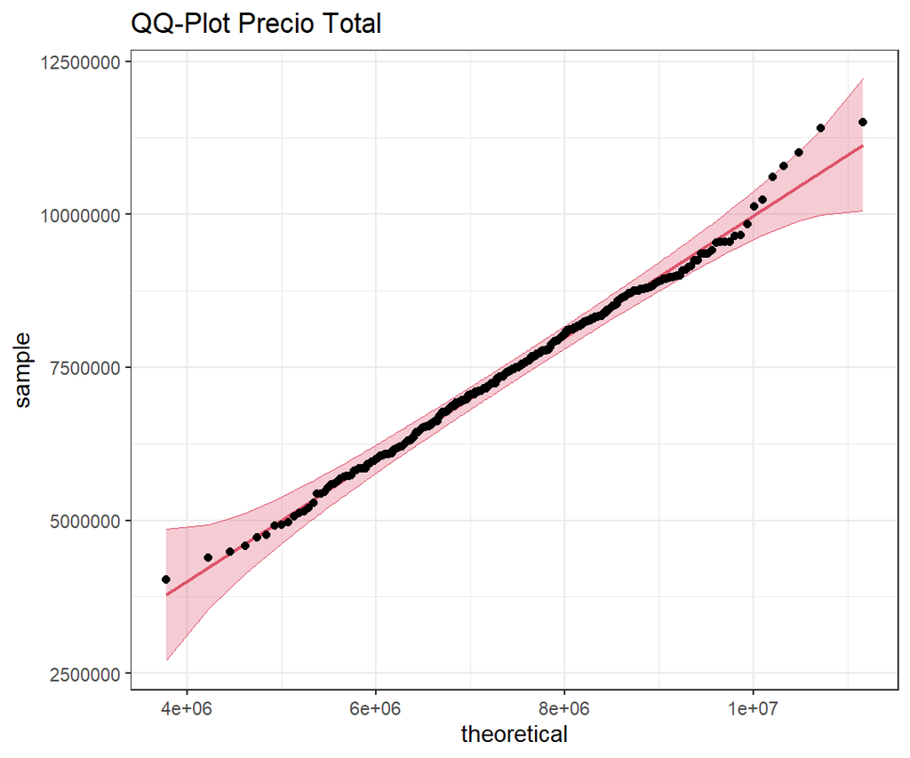

```r
Licores %>%
  ggplot(aes(sample=PT))+
  stat_qq_band(col=2,bg=2,alpha=0.3)+
  stat_qq_line(col=2)+
  stat_qq_point()+
  ggtitle("QQ-Plot Precio Total")+
  theme_bw()
```

```r
Licores %>%
  summarise(n=length(PT),Prom = mean(PT), DE=sd(PT),
            min=min(PT),max=max(PT),
            SW = shapiro.test(PT)$p.val, # Shapiro Wilks
            AD = ad.test(PT)$p.val, # Anderson Darling
            LF = lillie.test(PT)$p.val # Lilliefords
            )
```

```
##     n    Prom      DE     min      max       SW        AD       LF
## 1 300 7469031 1260031 4032823 11501602 0.413369 0.7248573 0.639334
```

Entonces, siguiendo el árbol de decisión tenemos que los datos se distribuyen normal y no conocemos los parámetros poblacionales, por lo tanto el estadístico de prueba está basado en la *t-student*.

```r
Licores %>%
  pull(PT) %>%
  t.test(mu = 7500000,
         alternative = "greater",
         conf.level = 0.95)
```

```
##
##  One Sample t-test
##
## data:  .
## t = -0.42571, df = 299, p-value = 0.6647
## alternative hypothesis: true mean is greater than 7500000
## 95 percent confidence interval:
##  7348999     Inf
## sample estimates:
## mean of x
##   7469031
```

### Punto 2

En la siguiente pregunta se pide calcular el *ipoconsumo* de acuerdo a una formulación, y luego comparar si el impuesto de los licores de tipo *Ron* son menores a los de *Whisky* basado en los promedios. Entonces tenemos la siguiente hipótesis:

$$H_0: \mu_{Ir} = \mu_{Iw} \qquad
H_a:\mu_{Ir} < \mu_{Iw}$$

De acuerdo al árbol de decisión tenemos que hacer los siguientes pasos:

- Calcular el ipoconsumo
- Separar la base de datos en Ron y Whisky
- Probar la normalidad de ambos grupos
- Comprobar la igualdad de varianzas de los grupos
- Escoger el mejor estadístico de prueba y realizar el análisis.
- Concluir

Los primeros dos pasos son sencillos:

```r
Licores <- Licores %>%
   mutate(IPO = GAQ*CE*400)

Licores %>%
  filter(TL %in% c("Ron","Whisky")) %>%
  droplevels %>%
  group_by(TL) %>%
  summarise(n=length(IPO),
            media=mean(IPO),
            desv=sd(IPO),
            min=min(IPO),
            max=max(IPO))
```

```
## # A tibble: 2 × 6
##   TL         n    media    desv      min      max
##   <fct>  <int>    <dbl>   <dbl>    <dbl>    <dbl>
## 1 Ron       52 3185673. 270971. 2557327. 3643167.
## 2 Whisky    27 3591694. 317110. 2842380. 4075807.
```

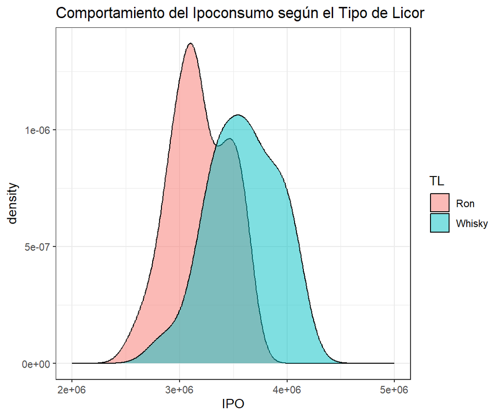

```r
Licores %>%
  filter(TL %in% c("Ron","Whisky")) %>%
  droplevels %>%
  ggplot(aes(x=IPO,fill=TL))+
  geom_density(alpha=0.5)+
  ggtitle("Comportamiento del Ipoconsumo según el Tipo de Licor")+
  xlim(c(2e06,5e06))+theme_bw()
```

Luego debemos probar la normalidad de los datos, esto lo podemos hacer de dos formas. La primera es separar la base de datos y construir dos nuevas con los grupos de interés, la otra es evaluar al mismo tiempo los valores-p de las pruebas usando `dplyr`.

$$H_0:IPO_R \sim N(\mu,\sigma^2) \qquad
H_a: IPO_R\not\sim N(\mu,\sigma^2)$$

$$H_0:IPO_W \sim N(\mu,\sigma^2) \qquad
H_a: IPO_W\not\sim N(\mu,\sigma^2)$$

```r
Licores %>%
  filter(TL %in% c("Ron","Whisky")) %>%
  droplevels %>% group_by(TL) %>%
  summarise(shapiro=shapiro.test(IPO)$p.val,
            Ander_Darl=ad.test(IPO)$p.val,
            lilliefords=lillie.test(IPO)$p.val)
```

```
## # A tibble: 2 × 4
##   TL     shapiro Ander_Darl lilliefords
##   <fct>    <dbl>      <dbl>       <dbl>
## 1 Ron      0.190      0.194       0.276
## 2 Whisky   0.519      0.671       0.864
```

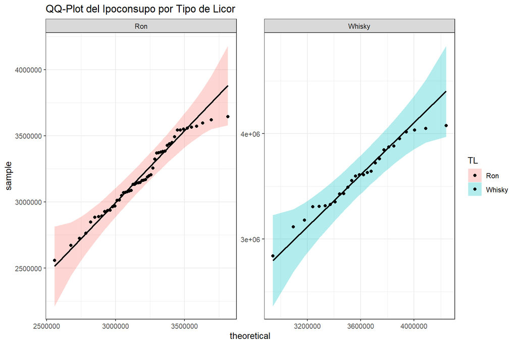

```r
Licores %>%
  filter(TL %in% c("Ron","Whisky")) %>%
  droplevels %>%
  ggplot(aes(sample=IPO,fill=TL))+
  stat_qq_band(alpha=0.3)+
  stat_qq_line()+
  stat_qq_point()+
  facet_wrap(~TL,scales = "free")+
  ggtitle("QQ-Plot del Ipoconsupo por Tipo de Licor")+
  theme_bw()
```

Como ambas muestras distribuyen normal, es necesario verificar si existe igualdad en sus varianzas, esto se comprueba con la función `var.test`.

$$H_0:
\frac{\sigma^2_{Ir}}{\sigma^2_{Iw}}=1 \qquad H_a:
\frac{\sigma^2_{Ir}}{\sigma^2_{Iw}}\neq 1$$

```r
Licores %>%
  filter(TL %in% c("Ron","Whisky")) %>%
  droplevels %>%
  with(.,var.test(IPO~TL))
```

```
##
##  F test to compare two variances
##
## data:  IPO by TL
## F = 0.73017, num df = 51, denom df = 26, p-value = 0.3333
## alternative hypothesis: true ratio of variances is not equal to 1
## 95 percent confidence interval:
##  0.3562148 1.3878542
## sample estimates:
## ratio of variances
##           0.730172
```

Entonces, como los datos son normales y tienen varianzas iguales, de acuerdo con el árbol de decisión el mejor estadístico de prueba está basado en la *t-student* y es necesario estimar la varianza conjunta, no obstante, el software lo hace:

```r
Licores %>%
  filter(TL %in% c("Ron","Whisky")) %>%
  droplevels %>%
  with(.,
       t.test(IPO~TL,
              var.equal = T,
              alternative = "less"))
```

```
##
##  Two Sample t-test
##
## data:  IPO by TL
## t = -5.9561, df = 77, p-value = 3.629e-08
## alternative hypothesis: true difference in means between group Ron and group Whisky is less than 0
## 95 percent confidence interval:
##       -Inf -292527.9
## sample estimates:
##    mean in group Ron mean in group Whisky
##              3185673              3591694
```

En conclusión, el ipoconsumo del ron es menor al del whisky con un nivel de significancia del 5%. Entonces la cantidad de impuestos que deja de percibir el departamento tiene mayor aporte en el Whisky, sin embargo, las cantidades de Ron son casi el doble que las de Whisky lo que sugiere que este licor es preferido para la adulteración. Los controles se deben aumentar para incautar más Ron y establecer una estrategia para que no aumente la adulteración del Whisky que es la que más afecta los recursos para salud.

### Punto 3

El tercer punto nos piden calcular una nueva variable, si $GAQ=GAE$ el licor se clasifica como **contrabando** en caso contrario se llamará **fraudulento**.

```r
Licores <- Licores %>%
   mutate(TI = factor(ifelse(GAQ==GAE,"Contrabando","Fraudulento")))
```

Luego preguntan si la proporción de licores Fraudulentos es superior al 65%. Entonces las hipótesis son:

$$H_0: p_F = 0.65 \qquad H_a: p_F
>0.65$$

```r
Licores %>%
  select(TI) %>%
  table()
```

```
## TI
## Contrabando Fraudulento
##          83         217
```

Como en `R` los factores se organizan alfabéticamente, entonces debemos cambiar la hipótesis hacia los licores de **contrabando**, así:

$$H_0: p_C = 0.35 \qquad H_a: p_C <
0.35$$

```r
Licores %>%
  select(TI) %>%
  table() %>%
  prop.test(p = 0.35,
            alternative = "less",
            conf.level = 0.95)
```

```
##
##  1-sample proportions test with continuity correction
##
## data:  ., null probability 0.35
## X-squared = 6.7729, df = 1, p-value = 0.004628
## alternative hypothesis: true p is less than 0.35
## 95 percent confidence interval:
##  0.0000000 0.3227318
## sample estimates:
##         p
## 0.2766667
```

Como el valor-p es mucho menor al nivel de significancia, entonces se rechaza $H_0$ por lo tanto existe evidencia muestral para afirmar que la proporción de licores Fraudulentos es mayor del 65%. Por lo tanto, las rentas ilegales de licores están basadas en mayor medida de la adulteración, el impacto para la salud pública es muy grave, pues los efectos nocivos de los licores que no son correctamente destilados aumenta los riesgos clínicos como la ceguera, el cáncer de órganos digestivos o la muerte.

### Punto 4

Para el cuarto punto nos piden determinar si los grados de alcohol son menores en los licores fraudulentos en comparación con los de contrabando, debido a que si los grados de alcohol disminuyen se va ver reflejado en la variable $GAQ$ y si los licores son de contrabando no se notará el cambio en los grados de alcohol.

$$H_0: \mu_{GAQf}=\mu_{GAQc} \qquad H_a:
\mu_{GAQf}<\mu_{GAQc}$$

- Verificar normalidad en ambos grupos.
- Verificar tamaños de muestra si al menos uno no distribuye normal.
- Verificar igualdad de varianzas si ambos distribuyen normal.
- Seleccionar el estadístico de prueba.
- Concluir.

En `R` es sencillo realizar estos pasos. Primero, podemos realizar un resumen numérico de los datos y evaluar la normalidad de los mismos.

$$H_0:GAQ_f \sim N(\mu,\sigma^2) \qquad
H_a: GAQ_f\not\sim N(\mu,\sigma^2)$$

$$H_0:GAQ_c \sim N(\mu,\sigma^2) \qquad
H_a: GAQ_c\not\sim N(\mu,\sigma^2)$$

```r
Licores %>% group_by(TI) %>%
  summarise(n=length(GAQ),
            media=mean(GAQ),
            desv=sd(GAQ),
            SW=shapiro.test(GAQ)$p,
            AD=ad.test(GAQ)$p,
            LF=lillie.test(GAQ)$p)
```

```
## # A tibble: 2 × 7
##   TI              n media  desv       SW       AD       LF
##   <fct>       <int> <dbl> <dbl>    <dbl>    <dbl>    <dbl>
## 1 Contrabando    83  33.4  4.36 1.86e-10 1.97e-22 8.00e-23
## 2 Fraudulento   217  29.8  3.88 4.86e-13 3.7 e-24 4.83e-23
```

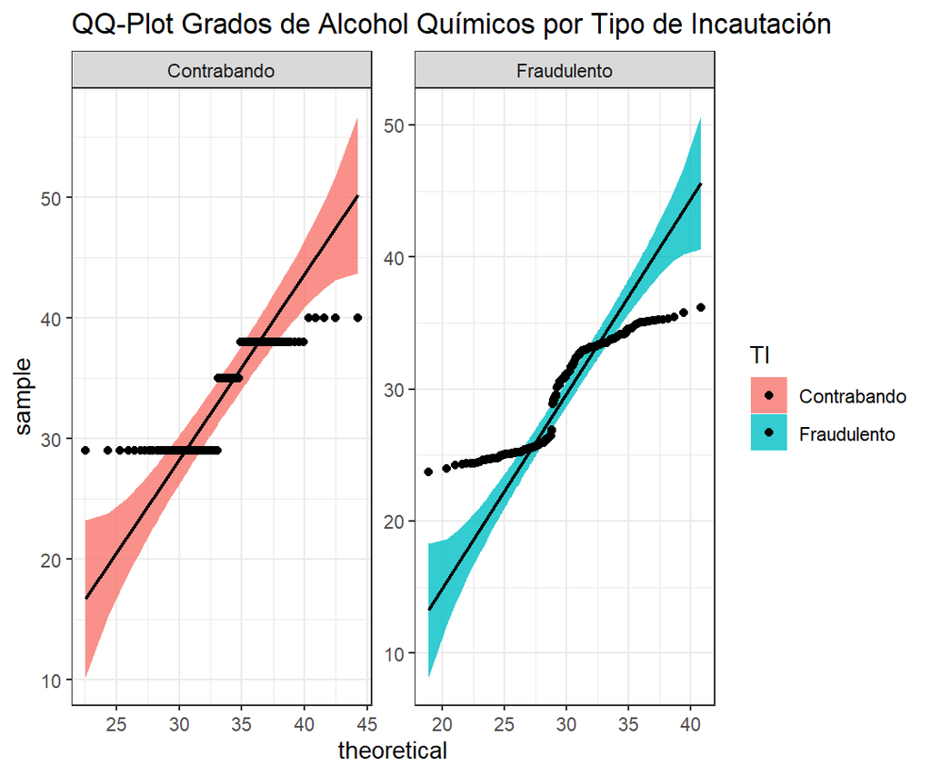

```r
Licores %>%
  ggplot(aes(sample=GAQ,fill=TI))+
  stat_qq_band()+
  stat_qq_line()+
  stat_qq_point()+
  facet_wrap(~TI,scales = "free")+
  ggtitle("QQ-Plot Grados de Alcohol Químicos por Tipo de Incautación")+
  theme_bw()
```

Como ambas muestras no distribuyen normal y los tamaños de muestra de ambos grupos son superiores a 30, podemos realizar el intervalo de confianza para la media, aproximando el resultado a una normal. En `R` existe un paquete para realizar estos intervalos, y al mismo tiempo verificar hipótesis, es muy similar al `t.test` la diferencia es que hay que especificarle los valores de las desviaciones estadándar de cada grupo. El paquete se llama `BSDA` y la función de interés es `z.test`.

```r
install.packages("BSDA",dependencies = T)
```

Para este ejercicio, sabemos que no contamos con información previa acerca de los datos, por lo tanto no conocemos las varianzas de los grados de alcohol por cada grupo, así que se debe utilizar las varianzas muestrales de cada uno.

```r
require(BSDA)

Licores %>%
  select(TI,GAQ) %>%
  with(.,
       z.test(x = GAQ[TI=="Fraudulento"],
              y = GAQ[TI=="Contrabando"],
              sigma.x = sd(GAQ[TI=="Fraudulento"]),
              sigma.y = sd(GAQ[TI=="Contrabando"]),
              alternative = "less"))
```

```
##
##  Two-sample z-Test
##
## data:  GAQ[TI == "Fraudulento"] and GAQ[TI == "Contrabando"]
## z = -6.5525, p-value = 2.829e-11
## alternative hypothesis: true difference in means is less than 0
## 95 percent confidence interval:
##         NA -2.679648
## sample estimates:
## mean of x mean of y
##  29.84393  33.42169
```

En conclusión, los grados de alcohol de los licores Fraudulentos son menores a los de Contrabando, ya que el valor-p es menor que el nivel de significancia del 5%, por lo tanto se rechaza la hipótesis nula. Entonces los ilegales que adulteran los licores, disminuyen significativamente los grados de alcohol, esto se explica porque los licores destilados contienen etanol que es más fácil de procesar para el hígado en comparación con el metanol que en su mayoría es utilizado para adulterar los licores, el cual produce envenenamiento. Si bien los grados de alcohol en los licores fraudulentos son menores, no significan que sean menos letales, debido a su composición química.

### Punto 5

En esta pregunta nos piden calcular una prueba de diferencia de proporciones, seleccionando primero los licores Aguardiente y Tequila, para compararlos según el Tipo de Incautación.

$$H_0: P_{Af}=P_{Tf} \qquad H_a:
P_{Af}>P_{Tf}$$

```
##              TI
## TL            Contrabando Fraudulento
##   Aguardiente          39          86
##   Tequila              26          70
```

Como la categoría de referencia para la comparación entre los licores en la tabla anterior es el Contrabando, por lo tanto es necesario intercambiar las columnas de la tabla.

```
##              TI
## TL            Fraudulento Contrabando
##   Aguardiente          86          39
##   Tequila              70          26
```

```
##
##  2-sample test for equality of proportions with continuity correction
##
## data:  .
## X-squared = 0.26712, df = 1, p-value = 0.6974
## alternative hypothesis: greater
## 95 percent confidence interval:
##  -0.1514279  1.0000000
## sample estimates:
##    prop 1    prop 2
## 0.6880000 0.7291667
```

Como el Valor-p es mayor que el nivel de significancia, entonces no se tiene evidencia muestral suficiente para asegurar que el Aguardiente se adultera más que el Tequila, por lo tanto la creencia del Equipo de Rentas no es correcta.